# Unit3: Design and Analysis of Experiments with Block Factors

Longhai Li

Feburary 2020

# Packages and Functions

```r
if (!require("lawstat")) {install.packages("lawstat"); library ("lawstat")}
if (!require("agricolae")) {install.packages("agricolae"); library ("agricolae")}
```

**A function with $R^2$ added to anova table output**

```r
anova.R2 <- function (obj.lm)
{
    obj.anova <- anova (obj.lm)
    sq <- obj.anova[,"Sum Sq"]
    R2 <- sq/sum(sq)
    obj.anova[, "R2"] <- R2
    obj.anova
}
```

# 1 Generate Designs with Computer

## 1.1 Randomized Complete Block Design

```r
treatments <- LETTERS[1:4]
design.rcbd(treatments, r=5)[c("book", "sketch")]
```

```
## $book
##    plots block treatments
## 1    101     1          D
## 2    102     1          A
## 3    103     1          B
## 4    104     1          C
## 5    201     2          C
## 6    202     2          D
## 7    203     2          A
## 8    204     2          B
## 9    301     3          D
## 10   302     3          A
## 11   303     3          C
## 12   304     3          B
## 13   401     4          D
## 14   402     4          B
## 15   403     4          A
## 16   404     4          C
## 17   501     5          D
## 18   502     5          A
## 19   503     5          B
## 20   504     5          C
##
## $sketch
##      [,1] [,2] [,3] [,4]
## [1,] "D"  "A"  "B"  "C"
## [2,] "C"  "D"  "A"  "B"
## [3,] "D"  "A"  "C"  "B"
## [4,] "D"  "B"  "A"  "C"
## [5,] "D"  "A"  "B"  "C"
```

```r
treatments2 <- c(LETTERS[1:4], LETTERS[1:4])
design.rcbd(treatments2, r=3)[c("book", "sketch")]
```

```
## $book
##    plots block treatments2
## 1    101     1           C
## 2    102     1           A
## 3    103     1           D
## 4    104     1           B
## 5    105     1           B
## 6    106     1           C
## 7    107     1           D
## 8    108     1           A
## 9    201     2           D
## 10   202     2           D
## 11   203     2           C
## 12   204     2           A
## 13   205     2           B
```

[output cut: 17 more lines]

## 1.2 Latin-Square Design

```r
treatments <- LETTERS[1:4]
design.lsd(treatments)[c("book", "sketch")]
```

```
## $book
##    plots row col treatments
## 1    101   1   1          A
## 2    102   1   2          C
## 3    103   1   3          B
## 4    104   1   4          D
## 5    201   2   1          B
## 6    202   2   2          D
## 7    203   2   3          C
## 8    204   2   4          A
## 9    301   3   1          D
## 10   302   3   2          B
## 11   303   3   3          A
## 12   304   3   4          C
## 13   401   4   1          C
## 14   402   4   2          A
## 15   403   4   3          D
## 16   404   4   4          B
##
## $sketch
##      [,1] [,2] [,3] [,4]
## [1,] "A"  "C"  "B"  "D"
## [2,] "B"  "D"  "C"  "A"
## [3,] "D"  "B"  "A"  "C"
## [4,] "C"  "A"  "D"  "B"
```

```r
## each treatment has been combined with each level of each block
lsd_des <- design.lsd(treatments)$book
lsd_des [order(lsd_des[,"treatments"]), ]
```

|  | plots | row | col | treatments |
| --- | --- | --- | --- | --- |
| 4 | 104 | 1 | 4 | A |
| 6 | 202 | 2 | 2 | A |
| 9 | 301 | 3 | 1 | A |
| 15 | 403 | 4 | 3 | A |
| 1 | 101 | 1 | 1 | B |
| 7 | 203 | 2 | 3 | B |
| 10 | 302 | 3 | 2 | B |
| 16 | 404 | 4 | 4 | B |
| 2 | 102 | 1 | 2 | C |
| 8 | 204 | 2 | 4 | C |
| 11 | 303 | 3 | 3 | C |
| 13 | 401 | 4 | 1 | C |
| 3 | 103 | 1 | 3 | D |
| 5 | 201 | 2 | 1 | D |
| 12 | 304 | 3 | 4 | D |
| 14 | 402 | 4 | 2 | D |

```r
## look at combination of factors
with (lsd_des, table(row, col))
```

```
##    col
## row 1 2 3 4
##   1 1 1 1 1
##   2 1 1 1 1
##   3 1 1 1 1
##   4 1 1 1 1
```

```r
with (lsd_des, table(row, treatments))
```

```
##    treatments
## row A B C D
##   1 1 1 1 1
##   2 1 1 1 1
##   3 1 1 1 1
##   4 1 1 1 1
```

```r
with (lsd_des, table(col, treatments))
```

```
##    treatments
## col A B C D
##   1 1 1 1 1
##   2 1 1 1 1
##   3 1 1 1 1
##   4 1 1 1 1
```

## 1.3 Graeco-Latin Design

```r
treat1 <- LETTERS[1:4]
treat2 <- letters[1:4]
gld <- design.graeco(treat1, treat2)[c("book", "sketch")]; gld
```

```
## $book
##    plots row col treat1 treat2
## 1    101   1   1      D      d
## 2    102   1   2      C      b
## 3    103   1   3      A      c
## 4    104   1   4      B      a
## 5    201   2   1      C      c
## 6    202   2   2      D      a
## 7    203   2   3      B      d
## 8    204   2   4      A      b
## 9    301   3   1      A      a
## 10   302   3   2      B      c
## 11   303   3   3      D      b
## 12   304   3   4      C      d
## 13   401   4   1      B      b
## 14   402   4   2      A      d
## 15   403   4   3      C      a
## 16   404   4   4      D      c
##
## $sketch
##      [,1]  [,2]  [,3]  [,4]
## [1,] "D d" "C b" "A c" "B a"
## [2,] "C c" "D a" "B d" "A b"
## [3,] "A a" "B c" "D b" "C d"
## [4,] "B b" "A d" "C a" "D c"
```

```r
## look at combination of factors
with(gld$book, table(row, col))
```

```
##    col
## row 1 2 3 4
##   1 1 1 1 1
##   2 1 1 1 1
##   3 1 1 1 1
##   4 1 1 1 1
```

```r
with(gld$book, table(row, treat1))
```

```
##    treat1
## row A B C D
##   1 1 1 1 1
##   2 1 1 1 1
##   3 1 1 1 1
##   4 1 1 1 1
```

```r
with(gld$book, table(row, treat2))
```

```
##    treat2
## row a b c d
##   1 1 1 1 1
##   2 1 1 1 1
##   3 1 1 1 1
##   4 1 1 1 1
```

```r
with(gld$book, table(col, treat1))
```

```
##    treat1
## col A B C D
##   1 1 1 1 1
##   2 1 1 1 1
##   3 1 1 1 1
##   4 1 1 1 1
```

```r
with(gld$book, table(col, treat2))
```

```
##    treat2
## col a b c d
##   1 1 1 1 1
##   2 1 1 1 1
##   3 1 1 1 1
##   4 1 1 1 1
```

## 1.4 Balanced Incomplete Block Design

```r
treatments <-  LETTERS[1:4]
bib.des <- design.bib (treatments, k=3)[c("book", "sketch")]; bib.des
```

```
##
## Parameters BIB
## ==============
## Lambda     : 2
## treatmeans : 4
## Block size : 3
## Blocks     : 4
## Replication: 3
##
## Efficiency factor 0.8888889
##
## <<< Book >>>
```

```
## $book
##    plots block treatments
## 1    101     1          C
## 2    102     1          A
## 3    103     1          B
## 4    201     2          D
## 5    202     2          B
## 6    203     2          C
## 7    301     3          C
## 8    302     3          D
## 9    303     3          A
## 10   401     4          B
## 11   402     4          A
## 12   403     4          D
##
## $sketch
##      [,1] [,2] [,3]
## [1,] "C"  "A"  "B"
## [2,] "D"  "B"  "C"
## [3,] "C"  "D"  "A"
## [4,] "B"  "A"  "D"
```

```r
with (bib.des$book, table (block))
```

```
## block
## 1 2 3 4
## 3 3 3 3
```

```r
with (bib.des$book, table (treatments))
```

```
## treatments
## A B C D
## 3 3 3 3
```

```r
with (bib.des$book, table (block, treatments))
```

```
##      treatments
## block A B C D
##     1 1 1 1 0
##     2 0 1 1 1
##     3 1 0 1 1
##     4 1 1 0 1
```

```r
treatments <-  LETTERS[1:4]
bib.des2 <- design.bib (treatments, k=2)[c("book", "sketch")]; bib.des2
```

```
##
## Parameters BIB
## ==============
## Lambda     : 1
## treatmeans : 4
## Block size : 2
## Blocks     : 6
## Replication: 3
##
## Efficiency factor 0.6666667
##
## <<< Book >>>
```

```
## $book
##    plots block treatments
## 1    101     1          C
## 2    102     1          A
## 3    201     2          B
## 4    202     2          C
## 5    301     3          D
## 6    302     3          C
## 7    401     4          A
## 8    402     4          D
## 9    501     5          A
## 10   502     5          B
## 11   601     6          D
## 12   602     6          B
##
## $sketch
##      [,1] [,2]
## [1,] "C"  "A"
## [2,] "B"  "C"
## [3,] "D"  "C"
## [4,] "A"  "D"
## [5,] "A"  "B"
## [6,] "D"  "B"
```

```r
with (bib.des2$book, table (block))
```

```
## block
## 1 2 3 4 5 6
## 2 2 2 2 2 2
```

```r
with (bib.des2$book, table (treatments))
```

```
## treatments
## A B C D
## 3 3 3 3
```

```r
with (bib.des2$book, table (block, treatments))
```

```
##      treatments
## block A B C D
##     1 1 0 1 0
##     2 0 1 1 0
##     3 0 0 1 1
##     4 1 0 0 1
##     5 1 1 0 0
##     6 0 1 0 1
```

# 2 Analyzing Randomized Complete Block Design

This is the example 4.1 from the textbook. A medical device manufacturer produces vascular grafts (artificial veins). These grafts are produced by extruding billets of polytetrafluoroethylene (PTFE) resin combined with a lubricant into tubes. Frequently, some of the tubes in a production run contain small, hard protrusions on the external surface. These defects are known as “flicks.” The defect is cause for rejection of the unit. The product developer responsible for the vascular grafts suspects that the extrusion pressure affects the occur- rence of yield and therefore intends to conduct an experi- ment to investigate this hypothesis. However, the resin is manufactured by an external supplier and is delivered to the medical device manufacturer in batches. The engineer also suspects that there may be significant batch-to-batch variation. Therefore, the product developer decided to investigate the effect of four different levels of extrusion pressure on yield using a randomized com- plete block design considering batches of resin as blocks. Note that there are four levels of extrusion pressure (treatments) and six batches of resin (blocks). Remember that the order in which the extrusion pressures are tested within each block is random. The response variable is yield, or the percentage of tubes in the production run that did not contain any flicks.

## 2.1 Read Data

```r
vascular <- data.frame (yield = scan ("data/vasculargraft.txt"),
                        batch = as.factor(rep(1:6,4)),
                        pressure = as.factor(rep (1:4, each = 6))
)
attach (vascular)## this command allows assessing values in vascular directly
vascular
```

| yield | batch | pressure |
| --- | --- | --- |
| 90.3 | 1 | 1 |
| 89.2 | 2 | 1 |
| 98.2 | 3 | 1 |
| 93.9 | 4 | 1 |
| 87.4 | 5 | 1 |
| 97.9 | 6 | 1 |
| 92.5 | 1 | 2 |
| 89.5 | 2 | 2 |
| 90.6 | 3 | 2 |
| 94.7 | 4 | 2 |
| 87.0 | 5 | 2 |
| 95.8 | 6 | 2 |
| 85.5 | 1 | 3 |
| 90.8 | 2 | 3 |
| 89.6 | 3 | 3 |
| 86.2 | 4 | 3 |
| 88.0 | 5 | 3 |
| 93.4 | 6 | 3 |
| 82.5 | 1 | 4 |
| 89.5 | 2 | 4 |
| 85.6 | 3 | 4 |
| 87.4 | 4 | 4 |
| 78.9 | 5 | 4 |
| 90.7 | 6 | 4 |

```r
## table display the data
tvascular <- tapply(yield, INDEX = list(batch, pressure), mean); tvascular
```

```
##      1    2    3    4
## 1 90.3 92.5 85.5 82.5
## 2 89.2 89.5 90.8 89.5
## 3 98.2 90.6 89.6 85.6
## 4 93.9 94.7 86.2 87.4
## 5 87.4 87.0 88.0 78.9
## 6 97.9 95.8 93.4 90.7
```

```r
tvascular <- cbind(tvascular, rowMeans(tvascular))
tvascular <- rbind (tvascular, colMeans(tvascular))
colnames(tvascular) <- c(paste0("Pressure", 1:4), "Average")
rownames(tvascular) <- c(paste0("Batch", 1:6), "Average")
tvascular
```

```
##         Pressure1 Pressure2 Pressure3 Pressure4  Average
## Batch1   90.30000  92.50000  85.50000  82.50000 87.70000
## Batch2   89.20000  89.50000  90.80000  89.50000 89.75000
## Batch3   98.20000  90.60000  89.60000  85.60000 91.00000
## Batch4   93.90000  94.70000  86.20000  87.40000 90.55000
## Batch5   87.40000  87.00000  88.00000  78.90000 85.32500
## Batch6   97.90000  95.80000  93.40000  90.70000 94.45000
## Average  92.81667  91.68333  88.91667  85.76667 89.79583
```

## 2.2 Visualize the Data

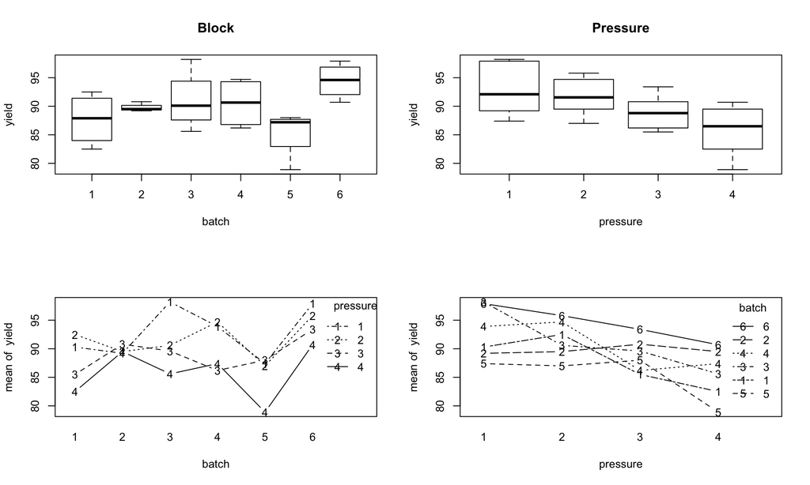

```r
par (mfrow = c(2,2))
#boxplot
plot(yield ~ batch, data=vascular, main = "Block")
plot(yield ~ pressure, data=vascular, main = "Pressure")
#interaction plot
with (vascular, interaction.plot(batch, pressure, yield, type = "b"))
with (vascular, interaction.plot( pressure,batch, yield, type = "b"))
```

## 2.3 Linear Models

### 2.3.1 Effect Model

```r
fit_vas_effect <- lm (yield ~  batch + pressure,
                      contrasts = list(batch=contr.sum, pressure=contr.sum),
                      data = vascular)

data.frame(batch,pressure,model.matrix(fit_vas_effect))
```

| batch | pressure | X.Intercept. | batch1 | batch2 | batch3 | batch4 | batch5 | pressure1 | pressure2 | pressure3 |
| --- | --- | --- | --- | --- | --- | --- | --- | --- | --- | --- |
| 1 | 1 | 1 | 1 | 0 | 0 | 0 | 0 | 1 | 0 | 0 |
| 2 | 1 | 1 | 0 | 1 | 0 | 0 | 0 | 1 | 0 | 0 |
| 3 | 1 | 1 | 0 | 0 | 1 | 0 | 0 | 1 | 0 | 0 |
| 4 | 1 | 1 | 0 | 0 | 0 | 1 | 0 | 1 | 0 | 0 |
| 5 | 1 | 1 | 0 | 0 | 0 | 0 | 1 | 1 | 0 | 0 |
| 6 | 1 | 1 | -1 | -1 | -1 | -1 | -1 | 1 | 0 | 0 |
| 1 | 2 | 1 | 1 | 0 | 0 | 0 | 0 | 0 | 1 | 0 |
| 2 | 2 | 1 | 0 | 1 | 0 | 0 | 0 | 0 | 1 | 0 |
| 3 | 2 | 1 | 0 | 0 | 1 | 0 | 0 | 0 | 1 | 0 |
| 4 | 2 | 1 | 0 | 0 | 0 | 1 | 0 | 0 | 1 | 0 |
| 5 | 2 | 1 | 0 | 0 | 0 | 0 | 1 | 0 | 1 | 0 |
| 6 | 2 | 1 | -1 | -1 | -1 | -1 | -1 | 0 | 1 | 0 |
| 1 | 3 | 1 | 1 | 0 | 0 | 0 | 0 | 0 | 0 | 1 |
| 2 | 3 | 1 | 0 | 1 | 0 | 0 | 0 | 0 | 0 | 1 |
| 3 | 3 | 1 | 0 | 0 | 1 | 0 | 0 | 0 | 0 | 1 |
| 4 | 3 | 1 | 0 | 0 | 0 | 1 | 0 | 0 | 0 | 1 |
| 5 | 3 | 1 | 0 | 0 | 0 | 0 | 1 | 0 | 0 | 1 |
| 6 | 3 | 1 | -1 | -1 | -1 | -1 | -1 | 0 | 0 | 1 |
| 1 | 4 | 1 | 1 | 0 | 0 | 0 | 0 | -1 | -1 | -1 |
| 2 | 4 | 1 | 0 | 1 | 0 | 0 | 0 | -1 | -1 | -1 |
| 3 | 4 | 1 | 0 | 0 | 1 | 0 | 0 | -1 | -1 | -1 |
| 4 | 4 | 1 | 0 | 0 | 0 | 1 | 0 | -1 | -1 | -1 |
| 5 | 4 | 1 | 0 | 0 | 0 | 0 | 1 | -1 | -1 | -1 |
| 6 | 4 | 1 | -1 | -1 | -1 | -1 | -1 | -1 | -1 | -1 |

```r
summary(fit_vas_effect)
```

```
##
## Call:
## lm(formula = yield ~ batch + pressure, data = vascular, contrasts = list(batch = contr.sum,
##     pressure = contr.sum))
##
## Residuals:
##     Min      1Q  Median      3Q     Max
## -3.5708 -1.3333 -0.3167  1.1417  4.1792
##
## Coefficients:
##             Estimate Std. Error t value Pr(>|t|)
## (Intercept) 89.79583    0.55248 162.531  < 2e-16 ***
## batch1      -2.09583    1.23539  -1.696  0.11044
## batch2      -0.04583    1.23539  -0.037  0.97089
## batch3       1.20417    1.23539   0.975  0.34516
## batch4       0.75417    1.23539   0.610  0.55069
## batch5      -4.47083    1.23539  -3.619  0.00253 **
## pressure1    3.02083    0.95693   3.157  0.00652 **
## pressure2    1.88750    0.95693   1.972  0.06728 .
## pressure3   -0.87917    0.95693  -0.919  0.37277
## ---
## Signif. codes:  0 '***' 0.001 '**' 0.01 '*' 0.05 '.' 0.1 ' ' 1
##
## Residual standard error: 2.707 on 15 degrees of freedom
## Multiple R-squared:  0.7712, Adjusted R-squared:  0.6492
## F-statistic: 6.321 on 8 and 15 DF,  p-value: 0.00113
```

```r
tvascular
```

```
##         Pressure1 Pressure2 Pressure3 Pressure4  Average
## Batch1   90.30000  92.50000  85.50000  82.50000 87.70000
## Batch2   89.20000  89.50000  90.80000  89.50000 89.75000
## Batch3   98.20000  90.60000  89.60000  85.60000 91.00000
## Batch4   93.90000  94.70000  86.20000  87.40000 90.55000
## Batch5   87.40000  87.00000  88.00000  78.90000 85.32500
## Batch6   97.90000  95.80000  93.40000  90.70000 94.45000
## Average  92.81667  91.68333  88.91667  85.76667 89.79583
```

```r
mu <- tvascular["Average", "Average"]
mu
```

```
## [1] 89.79583
```

```r
tau_pressure <- tvascular["Average",1:4]-tvascular["Average", "Average"]
tau_pressure
```

```
##  Pressure1  Pressure2  Pressure3  Pressure4
##  3.0208333  1.8875000 -0.8791667 -4.0291667
```

```r
tau_Batch <- tvascular[1:6,"Average"]-tvascular["Average", "Average"]
tau_Batch
```

```
##      Batch1      Batch2      Batch3      Batch4      Batch5      Batch6
## -2.09583333 -0.04583333  1.20416667  0.75416667 -4.47083333  4.65416667
```

### 2.3.2 Treatment Difference Model

```r
fit_vas <- lm (yield ~  batch + pressure, data = vascular)
data.frame(batch,pressure,model.matrix(fit_vas))
```

| batch | pressure | X.Intercept. | batch2 | batch3 | batch4 | batch5 | batch6 | pressure2 | pressure3 | pressure4 |
| --- | --- | --- | --- | --- | --- | --- | --- | --- | --- | --- |
| 1 | 1 | 1 | 0 | 0 | 0 | 0 | 0 | 0 | 0 | 0 |
| 2 | 1 | 1 | 1 | 0 | 0 | 0 | 0 | 0 | 0 | 0 |
| 3 | 1 | 1 | 0 | 1 | 0 | 0 | 0 | 0 | 0 | 0 |
| 4 | 1 | 1 | 0 | 0 | 1 | 0 | 0 | 0 | 0 | 0 |
| 5 | 1 | 1 | 0 | 0 | 0 | 1 | 0 | 0 | 0 | 0 |
| 6 | 1 | 1 | 0 | 0 | 0 | 0 | 1 | 0 | 0 | 0 |
| 1 | 2 | 1 | 0 | 0 | 0 | 0 | 0 | 1 | 0 | 0 |
| 2 | 2 | 1 | 1 | 0 | 0 | 0 | 0 | 1 | 0 | 0 |
| 3 | 2 | 1 | 0 | 1 | 0 | 0 | 0 | 1 | 0 | 0 |
| 4 | 2 | 1 | 0 | 0 | 1 | 0 | 0 | 1 | 0 | 0 |
| 5 | 2 | 1 | 0 | 0 | 0 | 1 | 0 | 1 | 0 | 0 |
| 6 | 2 | 1 | 0 | 0 | 0 | 0 | 1 | 1 | 0 | 0 |
| 1 | 3 | 1 | 0 | 0 | 0 | 0 | 0 | 0 | 1 | 0 |
| 2 | 3 | 1 | 1 | 0 | 0 | 0 | 0 | 0 | 1 | 0 |
| 3 | 3 | 1 | 0 | 1 | 0 | 0 | 0 | 0 | 1 | 0 |
| 4 | 3 | 1 | 0 | 0 | 1 | 0 | 0 | 0 | 1 | 0 |
| 5 | 3 | 1 | 0 | 0 | 0 | 1 | 0 | 0 | 1 | 0 |
| 6 | 3 | 1 | 0 | 0 | 0 | 0 | 1 | 0 | 1 | 0 |
| 1 | 4 | 1 | 0 | 0 | 0 | 0 | 0 | 0 | 0 | 1 |
| 2 | 4 | 1 | 1 | 0 | 0 | 0 | 0 | 0 | 0 | 1 |
| 3 | 4 | 1 | 0 | 1 | 0 | 0 | 0 | 0 | 0 | 1 |
| 4 | 4 | 1 | 0 | 0 | 1 | 0 | 0 | 0 | 0 | 1 |
| 5 | 4 | 1 | 0 | 0 | 0 | 1 | 0 | 0 | 0 | 1 |
| 6 | 4 | 1 | 0 | 0 | 0 | 0 | 1 | 0 | 0 | 1 |

```r
summary(fit_vas)
```

```
##
## Call:
## lm(formula = yield ~ batch + pressure, data = vascular)
##
## Residuals:
##     Min      1Q  Median      3Q     Max
## -3.5708 -1.3333 -0.3167  1.1417  4.1792
##
## Coefficients:
##             Estimate Std. Error t value Pr(>|t|)
## (Intercept)   90.721      1.657  54.735  < 2e-16 ***
## batch2         2.050      1.914   1.071 0.301043
## batch3         3.300      1.914   1.724 0.105201
## batch4         2.850      1.914   1.489 0.157175
## batch5        -2.375      1.914  -1.241 0.233684
## batch6         6.750      1.914   3.527 0.003050 **
## pressure2     -1.133      1.563  -0.725 0.479457
## pressure3     -3.900      1.563  -2.496 0.024713 *
## pressure4     -7.050      1.563  -4.512 0.000414 ***
## ---
## Signif. codes:  0 '***' 0.001 '**' 0.01 '*' 0.05 '.' 0.1 ' ' 1
##
## Residual standard error: 2.707 on 15 degrees of freedom
## Multiple R-squared:  0.7712, Adjusted R-squared:  0.6492
## F-statistic: 6.321 on 8 and 15 DF,  p-value: 0.00113
```

```r
tvascular
```

```
##         Pressure1 Pressure2 Pressure3 Pressure4  Average
## Batch1   90.30000  92.50000  85.50000  82.50000 87.70000
## Batch2   89.20000  89.50000  90.80000  89.50000 89.75000
## Batch3   98.20000  90.60000  89.60000  85.60000 91.00000
## Batch4   93.90000  94.70000  86.20000  87.40000 90.55000
## Batch5   87.40000  87.00000  88.00000  78.90000 85.32500
## Batch6   97.90000  95.80000  93.40000  90.70000 94.45000
## Average  92.81667  91.68333  88.91667  85.76667 89.79583
```

```r
tvascular["Average",2:4]-tvascular["Average", 1]
```

```
## Pressure2 Pressure3 Pressure4
## -1.133333 -3.900000 -7.050000
```

```r
tvascular[2:6,"Average"]-tvascular[1,"Average"]
```

```
## Batch2 Batch3 Batch4 Batch5 Batch6
##  2.050  3.300  2.850 -2.375  6.750
```

```r
## The intercept of treatment difference model is:
mu + tau_Batch[1] + tau_pressure[1]
```

```
##   Batch1
## 90.72083
```

### 2.3.3 Visualize the fitted model

```r
summary(fit_vas)
```

```
##
## Call:
## lm(formula = yield ~ batch + pressure, data = vascular)
##
## Residuals:
##     Min      1Q  Median      3Q     Max
## -3.5708 -1.3333 -0.3167  1.1417  4.1792
##
## Coefficients:
##             Estimate Std. Error t value Pr(>|t|)
## (Intercept)   90.721      1.657  54.735  < 2e-16 ***
## batch2         2.050      1.914   1.071 0.301043
## batch3         3.300      1.914   1.724 0.105201
## batch4         2.850      1.914   1.489 0.157175
## batch5        -2.375      1.914  -1.241 0.233684
## batch6         6.750      1.914   3.527 0.003050 **
## pressure2     -1.133      1.563  -0.725 0.479457
## pressure3     -3.900      1.563  -2.496 0.024713 *
## pressure4     -7.050      1.563  -4.512 0.000414 ***
## ---
## Signif. codes:  0 '***' 0.001 '**' 0.01 '*' 0.05 '.' 0.1 ' ' 1
##
## Residual standard error: 2.707 on 15 degrees of freedom
## Multiple R-squared:  0.7712, Adjusted R-squared:  0.6492
## F-statistic: 6.321 on 8 and 15 DF,  p-value: 0.00113
```

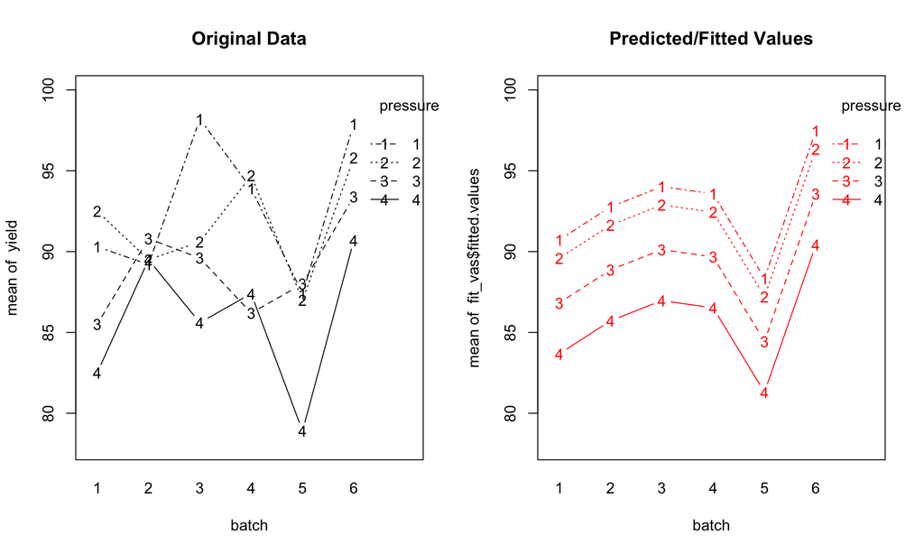

```r
par (mfrow = c(1,2))

with (vascular,
      interaction.plot(batch, pressure, yield, type = "b", col = "black",
                       main = "Original Data", ylim = c(78,100))
)
with (vascular,
      interaction.plot(batch, pressure, fit_vas$fitted.values, type = "b", col = "red",
                       main = "Predicted/Fitted Values", ylim = c(78,100)))
```

## 2.4 ANOVA

### 2.4.1 Formulae

The formula for computing block and treatment sum squares is the same as in one-way ANOVA.

```r
tvascular
```

```
##         Pressure1 Pressure2 Pressure3 Pressure4  Average
## Batch1   90.30000  92.50000  85.50000  82.50000 87.70000
## Batch2   89.20000  89.50000  90.80000  89.50000 89.75000
## Batch3   98.20000  90.60000  89.60000  85.60000 91.00000
## Batch4   93.90000  94.70000  86.20000  87.40000 90.55000
## Batch5   87.40000  87.00000  88.00000  78.90000 85.32500
## Batch6   97.90000  95.80000  93.40000  90.70000 94.45000
## Average  92.81667  91.68333  88.91667  85.76667 89.79583
```

```r
## Total sum squares:

sum(tvascular[1:6,1:4]^2) - 24 * mu^2->SST; SST
```

```
## [1] 480.3096
```

```r
## pressure sum squares:

sum(tvascular["Average",1:4]^2 * 6)-24*mu^2->SStr; SStr
```

```
## [1] 178.1712
```

```r
## batch sum squares:

sum(tvascular[1:6, "Average"]^2 * 4)-24*mu^2->SSblock; SSblock
```

```
## [1] 192.2521
```

```r
## SSE:

SST - SStr - SSblock
```

```
## [1] 109.8863
```

### 2.4.2 Using lm and anova functions

```r
fit_pressure <- lm (yield~pressure, data = vascular)
anova (fit_pressure)
```

|  | Df | Sum Sq | Mean Sq | F value | Pr(>F) |
| --- | --- | --- | --- | --- | --- |
| pressure | 3 | 178.1712 | 59.39042 | 3.931339 | 0.023448 |
| Residuals | 20 | 302.1383 | 15.10692 | NA | NA |

```r
fit_batch <- lm (yield~batch, data = vascular)

anova (fit_batch)
```

|  | Df | Sum Sq | Mean Sq | F value | Pr(>F) |
| --- | --- | --- | --- | --- | --- |
| batch | 5 | 192.2521 | 38.45042 | 2.402671 | 0.0777009 |
| Residuals | 18 | 288.0575 | 16.00319 | NA | NA |

```r
## Due to the orthogonality in pressure and batch, the following two ways for anova are the same:
fit_batch_pressure <- lm (yield~batch+pressure, data = vascular)

anova (fit_batch_pressure)
```

|  | Df | Sum Sq | Mean Sq | F value | Pr(>F) |
| --- | --- | --- | --- | --- | --- |
| batch | 5 | 192.2521 | 38.45042 | 5.248666 | 0.0055317 |
| pressure | 3 | 178.1712 | 59.39042 | 8.107077 | 0.0019163 |
| Residuals | 15 | 109.8863 | 7.32575 | NA | NA |

```r
fit_pressure_batch <- lm (yield~pressure + batch, data = vascular)

anova (fit_pressure_batch)
```

|  | Df | Sum Sq | Mean Sq | F value | Pr(>F) |
| --- | --- | --- | --- | --- | --- |
| pressure | 3 | 178.1712 | 59.39042 | 8.107077 | 0.0019163 |
| batch | 5 | 192.2521 | 38.45042 | 5.248666 | 0.0055317 |
| Residuals | 15 | 109.8863 | 7.32575 | NA | NA |

## 2.5 Effect Comparison

### 2.5.1 Standard Error of the Difference Between Two Means

$$se(\hat \mu_i-\hat \mu_j)=\hat\sigma\times \sqrt{1/n_i+1/n_j}$$
where $\hat\sigma=\sqrt{MSE}$ from the treatment+block model. This SE will be multiplied by the t quantile or Tukey quantiles to obtain the LSD CI or family-wise CI.

### 2.5.2 Effect Comparison for Fixed Pair with LSD

```r
cbind(summary (fit_vas)$coef, confint(fit_vas))
```

```
##              Estimate Std. Error    t value     Pr(>|t|)       2.5 %    97.5 %
## (Intercept) 90.720833   1.657455 54.7350287 1.091578e-18  87.1880522 94.253615
## batch2       2.050000   1.913864  1.0711316 3.010429e-01  -2.0293043  6.129304
## batch3       3.300000   1.913864  1.7242605 1.052012e-01  -0.7793043  7.379304
## batch4       2.850000   1.913864  1.4891341 1.571751e-01  -1.2293043  6.929304
## batch5      -2.375000   1.913864 -1.2409451 2.336842e-01  -6.4543043  1.704304
## batch6       6.750000   1.913864  3.5268966 3.050449e-03   2.6706957 10.829304
## pressure2   -1.133333   1.562663 -0.7252575 4.794567e-01  -4.4640714  2.197405
## pressure3   -3.900000   1.562663 -2.4957391 2.471273e-02  -7.2307380 -0.569262
## pressure4   -7.050000   1.562663 -4.5115284 4.136854e-04 -10.3807380 -3.719262
```

```r
## hand calculation of SE
SE_diff_blocks <- sigma (fit_vas) * sqrt(1/4+1/4); SE_diff_blocks # 4 is number of treatment levels
```

```
## [1] 1.913864
```

```r
SE_diff_treats <- sigma (fit_vas) * sqrt (1/6+1/6); SE_diff_treats # 6 is number of block levels
```

```
## [1] 1.562663
```

```r
## ME in LSD (without correction for multiple comparison bias, illustration for hand calculation)
SE_diff_blocks* qt (0.975, df = 15) ## for blocks
```

```
## [1] 4.079304
```

```r
SE_diff_treats* qt (0.975, df = 15) ## for treatments
```

```
## [1] 3.330738
```

### 2.5.3 Tukey Multiple Comparison of Effects

```r
TukeyHSD(aov (yield~pressure + batch, vascular))
```

```
##   Tukey multiple comparisons of means
##     95% family-wise confidence level
##
## Fit: aov(formula = yield ~ pressure + batch, data = vascular)
##
## $pressure
##          diff        lwr       upr     p adj
## 2-1 -1.133333  -5.637161  3.370495 0.8854831
## 3-1 -3.900000  -8.403828  0.603828 0.1013084
## 4-1 -7.050000 -11.553828 -2.546172 0.0020883
## 3-2 -2.766667  -7.270495  1.737161 0.3245644
## 4-2 -5.916667 -10.420495 -1.412839 0.0086667
## 4-3 -3.150000  -7.653828  1.353828 0.2257674
##
## $batch
##       diff         lwr        upr     p adj
## 2-1  2.050  -4.1680828  8.2680828 0.8853016
## 3-1  3.300  -2.9180828  9.5180828 0.5376297
## 4-1  2.850  -3.3680828  9.0680828 0.6757699
## 5-1 -2.375  -8.5930828  3.8430828 0.8105903
## 6-1  6.750   0.5319172 12.9680828 0.0297368
## 3-2  1.250  -4.9680828  7.4680828 0.9845521
## 4-2  0.800  -5.4180828  7.0180828 0.9980198
## 5-2 -4.425 -10.6430828  1.7930828 0.2483499
## 6-2  4.700  -1.5180828 10.9180828 0.1986961
## 4-3 -0.450  -6.6680828  5.7680828 0.9998784
## 5-3 -5.675 -11.8930828  0.5430828 0.0837504
## 6-3  3.450  -2.7680828  9.6680828 0.4925715
## 5-4 -5.225 -11.4430828  0.9930828 0.1263042
## 6-4  3.900  -2.3180828 10.1180828 0.3674672
## 6-5  9.125   2.9069172 15.3430828 0.0027838
```

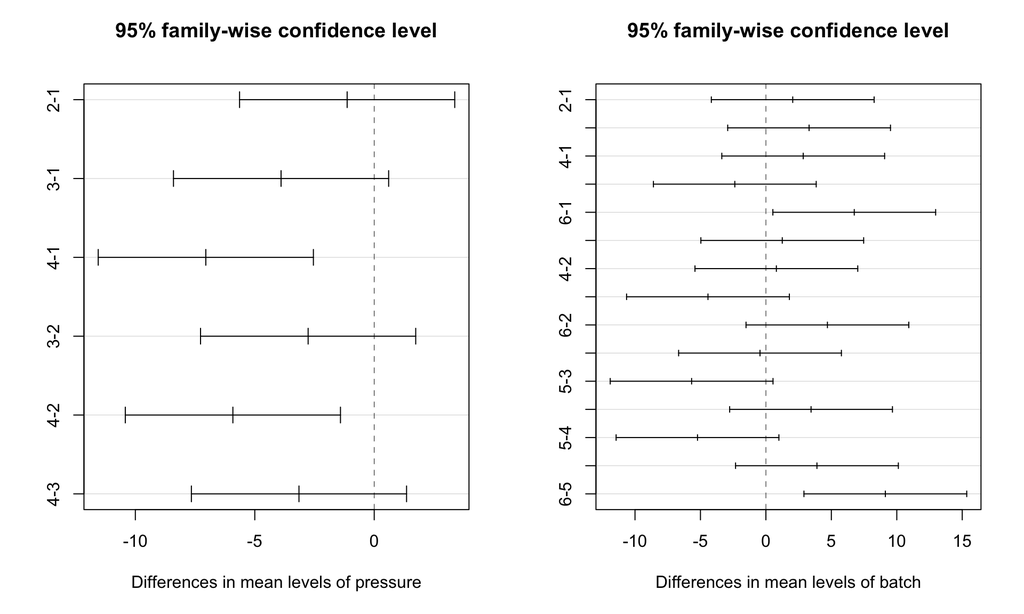

```r
par (mfrow = c(1,2))
plot(TukeyHSD(aov (yield~pressure + batch, vascular)))
```

```r
## ME for Tukey CI (illustration for hand computing)
SE_diff_blocks * qtukey(0.95, 6, df = 15)/sqrt(2) ## for blocks
```

```
## [1] 6.218083
```

```r
SE_diff_treats * qtukey(0.95, 4, df = 15)/sqrt(2) ## for treatments
```

```
## [1] 4.503828
```

## 2.6 Model Checking

### 2.6.1 Checking the treatment or block only model

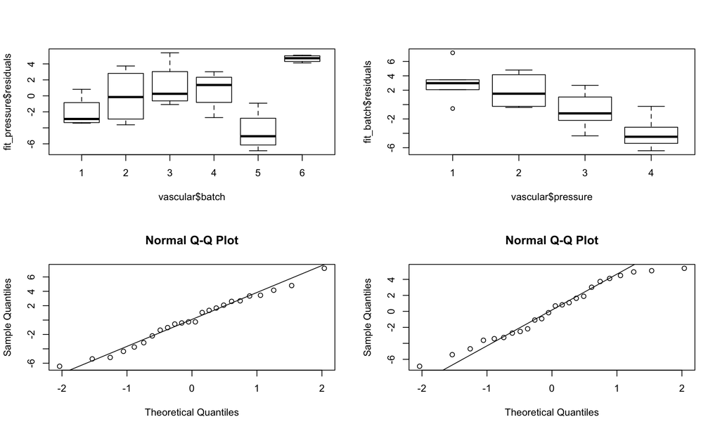

```r
par(mfrow=c(2,2))
plot(fit_pressure$residuals ~vascular$batch)
plot(fit_batch$residuals ~vascular$pressure)
qqnorm(fit_batch$residuals)
qqline(fit_batch$residuals)
qqnorm(fit_pressure$residuals)
qqline(fit_pressure$residuals)
```

```r
shapiro.test(fit_batch$residuals)
```

```
##
##  Shapiro-Wilk normality test
##
## data:  fit_batch$residuals
## W = 0.98098, p-value = 0.9132
```

```r
shapiro.test(fit_pressure$residuals)
```

```
##
##  Shapiro-Wilk normality test
##
## data:  fit_pressure$residuals
## W = 0.95664, p-value = 0.3747
```

From the boxplots of residuals versus un-accounted variables, we can see clearly that there are still signals uncaptured. However, the normality test for the residuals of each model may tell you that the model is not bad good. To compare (not check) the goodness of fits of different models, another criteria, AIC, is often used. AIC is a criterion related to sum squares of residuals and the number of parameters.

```r
AIC(fit_batch)
```

```
## [1] 141.7516
```

```r
AIC(fit_pressure)
```

```
## [1] 138.897
```

```r
AIC(fit_batch_pressure)
```

```
## [1] 124.6225
```

```r
#overall normality
par (mfrow =c(1,3))
qqnorm(fit_vas$res)
qqline(fit_vas$res)
shapiro.test(fit_vas$res)
```

```
##
##  Shapiro-Wilk normality test
##
## data:  fit_vas$res
## W = 0.95631, p-value = 0.3689
```

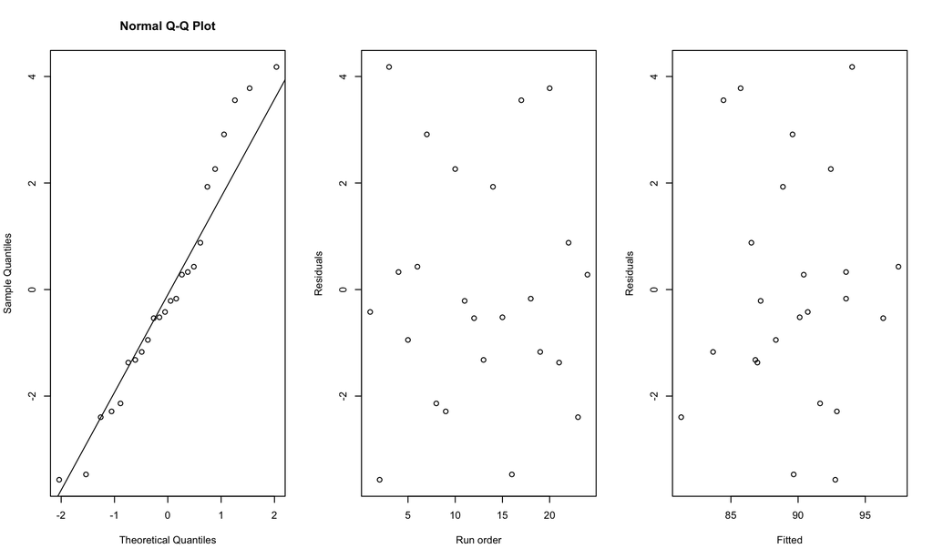

```r
#independence
plot(fit_vas$res,xlab="Run order",ylab="Residuals")
#constant variance
plot(fit_vas$fitted,fit_vas$res,xlab="Fitted",ylab="Residuals")
```

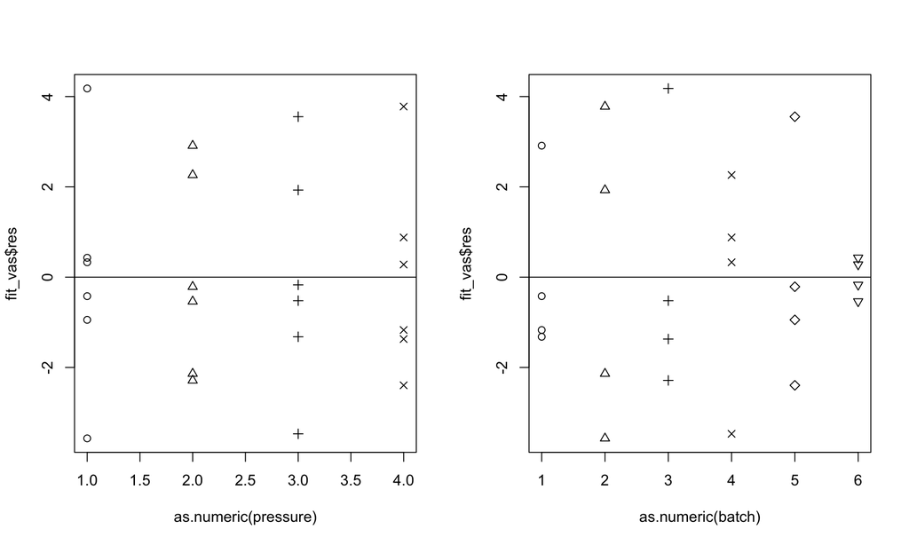

```r
#residual plots of residuals vs. pressurement labels, block labels
par (mfrow = c(1,2))
with(vascular,plot(fit_vas$res~as.numeric(pressure), pch = as.numeric(pressure) ) )
abline(h=0)

with(vascular,plot(fit_vas$res~as.numeric(batch), pch = as.numeric(batch) ) )
abline(h=0)
```

```r
# levene test for constant variances within each pressurement or each block
par (mfrow = c(1,2))

anova (lm(abs(fit_vas$residuals)~vascular$batch))
```

|  | Df | Sum Sq | Mean Sq | F value | Pr(>F) |
| --- | --- | --- | --- | --- | --- |
| vascular$batch | 5 | 13.44405 | 2.688810 | 1.84921 | 0.1538582 |
| Residuals | 18 | 26.17257 | 1.454032 | NA | NA |

```r
anova (lm(abs(fit_vas$residuals)~vascular$pressure))
```

|  | Df | Sum Sq | Mean Sq | F value | Pr(>F) |
| --- | --- | --- | --- | --- | --- |
| vascular$pressure | 3 | 0.1339583 | 0.0446528 | 0.0226189 | 0.9952375 |
| Residuals | 20 | 39.4826620 | 1.9741331 | NA | NA |

```r
#detach the dataset
#detach ("vascular")
```

# 3 Analyzing Latin Square Design Experiments

A hardness testing machine presses a pointed rod (the ‘tip’) into a metal specimen (a ‘coupon’), with a known force. The depth of the depression is a measure of the hardness of the specimen. It is feared that, depending on the kind of tip used, the machine might give different readings. The experimenter wants 4 observations on each of the 4 types of tips. Suppose that the ‘coupon’ and the ‘operator’ of the testing machine are thought to be factors. Suppose there are p = 4 operators, p = 4 coupons, and p = 4 tips. The first two are nuisance factors, the last is the treatment factor.

```r
# read data
hardness <- read.table("data/hardness.txt",
                       header=T,
                       colClasses=c("factor","factor","factor","numeric"))

attach(hardness)
hardness
```

| operator | coupon | tip | y |
| --- | --- | --- | --- |
| 1 | 1 | A | 9.3 |
| 1 | 2 | B | 9.4 |
| 1 | 3 | C | 9.2 |
| 1 | 4 | D | 9.7 |
| 2 | 1 | B | 9.3 |
| 2 | 2 | A | 9.4 |
| 2 | 3 | D | 9.6 |
| 2 | 4 | C | 9.4 |
| 3 | 1 | C | 9.5 |
| 3 | 2 | D | 10.0 |
| 3 | 3 | A | 9.6 |
| 3 | 4 | B | 9.8 |
| 4 | 1 | D | 10.2 |
| 4 | 2 | C | 9.7 |
| 4 | 3 | B | 9.9 |
| 4 | 4 | A | 10.0 |

```r
## verifying a latin square design
table (operator, tip)
```

```
##         tip
## operator A B C D
##        1 1 1 1 1
##        2 1 1 1 1
##        3 1 1 1 1
##        4 1 1 1 1
```

```r
table (operator, coupon)
```

```
##         coupon
## operator 1 2 3 4
##        1 1 1 1 1
##        2 1 1 1 1
##        3 1 1 1 1
##        4 1 1 1 1
```

```r
table (coupon, tip)
```

```
##       tip
## coupon A B C D
##      1 1 1 1 1
##      2 1 1 1 1
##      3 1 1 1 1
##      4 1 1 1 1
```

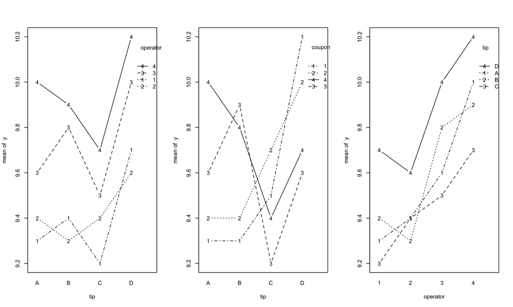

```r
## look at the data

par (mfrow = c(1,3))
with (hardness, interaction.plot(tip,operator,y, type = "b"))
with (hardness, interaction.plot(tip,coupon,y, type = "b"))
with (hardness, interaction.plot(operator,tip,y, type = "b"))
```

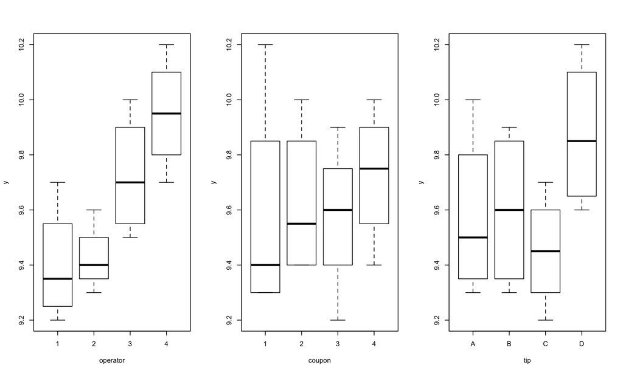

```r
par (mfrow = c(1,3))
plot (y~operator)
plot (y~coupon)
plot (y~tip)
```

```r
## fit the model and anova
g <- lm(y ~ operator + coupon + tip, hardness)
summary (g)
```

```
##
## Call:
## lm(formula = y ~ operator + coupon + tip, data = hardness)
##
## Residuals:
##    Min     1Q Median     3Q    Max
## -0.075 -0.025  0.000  0.025  0.050
##
## Coefficients:
##               Estimate Std. Error t value Pr(>|t|)
## (Intercept)  9.300e+00  4.564e-02 203.753 9.43e-13 ***
## operator2    2.500e-02  4.082e-02   0.612 0.562764
## operator3    3.250e-01  4.082e-02   7.961 0.000209 ***
## operator4    5.500e-01  4.082e-02  13.472 1.04e-05 ***
## coupon2      5.000e-02  4.082e-02   1.225 0.266570
## coupon3      9.433e-16  4.082e-02   0.000 1.000000
## coupon4      1.500e-01  4.082e-02   3.674 0.010402 *
## tipB         2.500e-02  4.082e-02   0.612 0.562764
## tipC        -1.250e-01  4.082e-02  -3.062 0.022172 *
## tipD         3.000e-01  4.082e-02   7.348 0.000325 ***
## ---
## Signif. codes:  0 '***' 0.001 '**' 0.01 '*' 0.05 '.' 0.1 ' ' 1
##
## Residual standard error: 0.05774 on 6 degrees of freedom
## Multiple R-squared:  0.9845, Adjusted R-squared:  0.9612
## F-statistic: 42.33 on 9 and 6 DF,  p-value: 9.592e-05
```

```r
anova.R2(g)
```

|  | Df | Sum Sq | Mean Sq | F value | Pr(>F) | R2 |
| --- | --- | --- | --- | --- | --- | --- |
| operator | 3 | 0.825 | 0.2750000 | 82.5 | 0.0000287 | 0.6395349 |
| coupon | 3 | 0.060 | 0.0200000 | 6.0 | 0.0307958 | 0.0465116 |
| tip | 3 | 0.385 | 0.1283333 | 38.5 | 0.0002585 | 0.2984496 |
| Residuals | 6 | 0.020 | 0.0033333 | NA | NA | 0.0155039 |

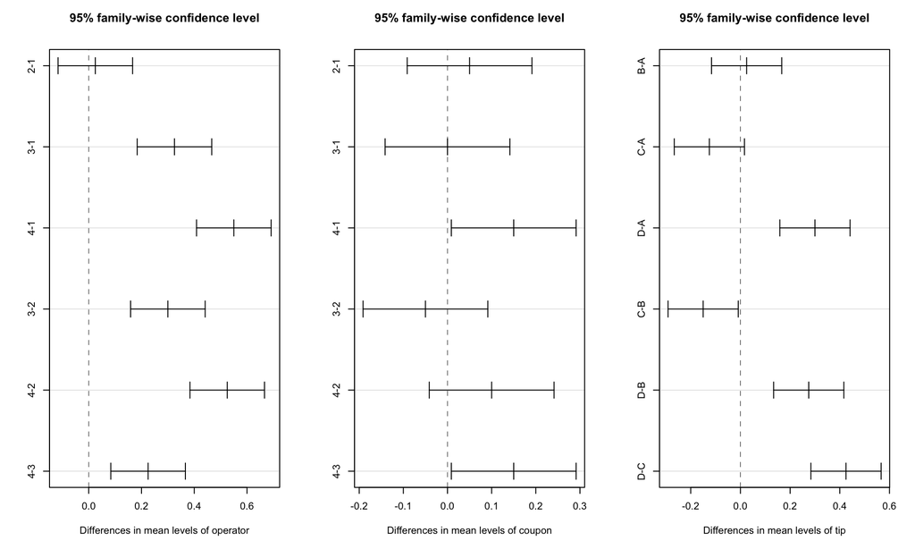

```r
## Tukey Multiple Comparison
plot(TukeyHSD(aov(g)))
```

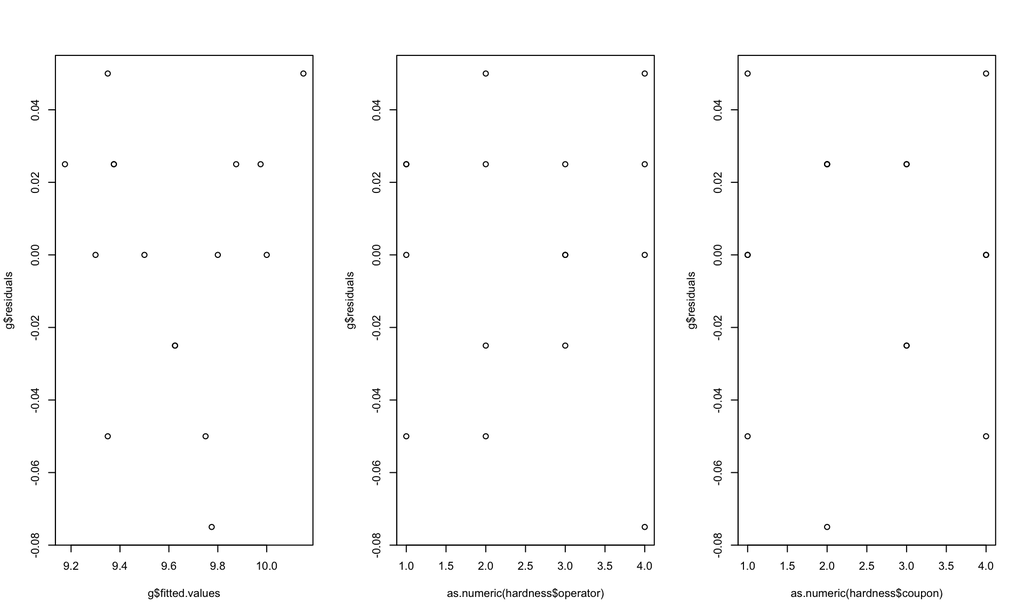

```r
## model diagnosis
#plot(g)
plot (g$residuals~ g$fitted.values)
plot (g$residuals~ as.numeric(hardness$operator))
plot (g$residuals~ as.numeric(hardness$coupon))
```

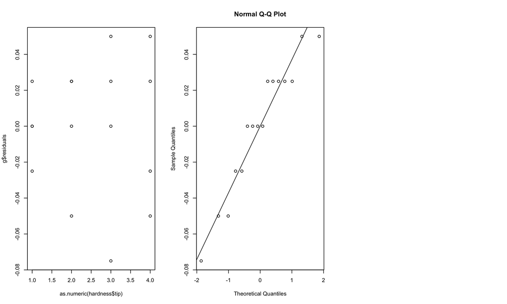

```r
plot (g$residuals~ as.numeric(hardness$tip))
qqnorm (g$residuals); qqline(g$residuals)
##
detach ("hardness")
```

# 4 Analyzing Balanced Incomplete Block Design

Suppose that a chemical engineer thinks that the time of reaction for a chemical process is a function of the type of catalyst employed. Four catalysts are currently being investigated. The experimental procedure consists of selecting a batch of raw material, loading the pilot plant, applying each catalyst in a separate run of the pilot plant, and observing the reaction time. Because variations in the batches of raw material may affect the performance of the catalysts, the engineer decides to use batches of raw material as blocks. However, each batch is only large enough to permit three catalysts to be run. Therefore a randomized incomplete block design must be used.

```r
catalyst <- read.table("data/catalyst.txt", header=T, colClasses=c("factor","factor","numeric"))
catalyst
```

| Treatment | Block | y |
| --- | --- | --- |
| 1 | 1 | 73 |
| 1 | 2 | 74 |
| 1 | 4 | 71 |
| 2 | 2 | 75 |
| 2 | 3 | 67 |
| 2 | 4 | 72 |
| 3 | 1 | 73 |
| 3 | 2 | 75 |
| 3 | 3 | 68 |
| 4 | 1 | 75 |
| 4 | 3 | 72 |
| 4 | 4 | 75 |

```r
attach(catalyst)

## check the design
table (Block, Treatment)
```

```
##      Treatment
## Block 1 2 3 4
##     1 1 0 1 1
##     2 1 1 1 0
##     3 0 1 1 1
##     4 1 1 0 1
```

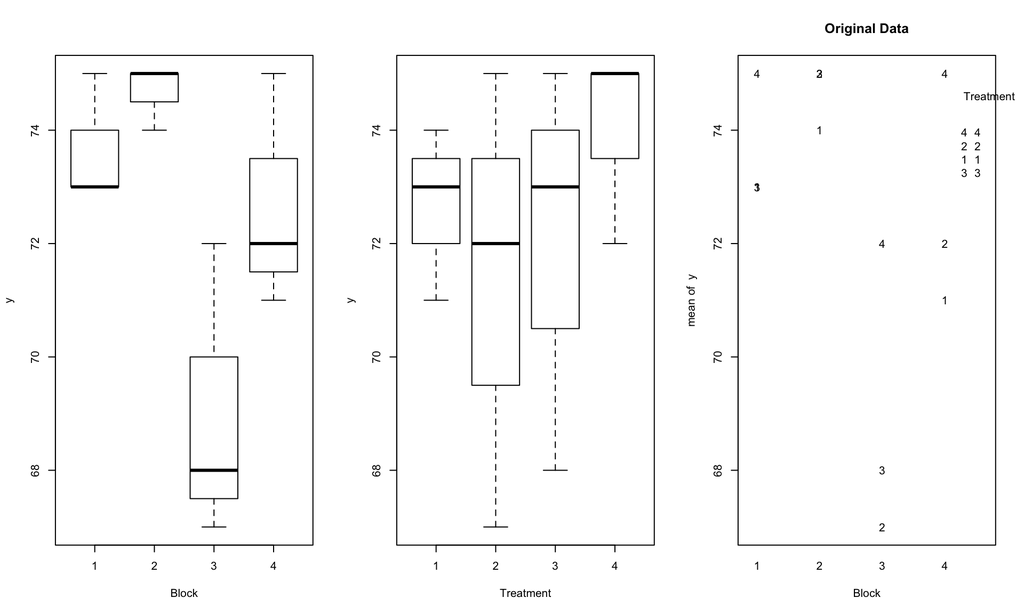

```r
## look at the dataset
par (mfrow = c(1,3))
plot (y~Block)
plot (y~Treatment)
interaction.plot(Block, Treatment, y, type ="p", main = "Original Data")
```

## 4.1 Fitting Linear Model and ANOVA

```r
## fit linear model (block then treatment)
g<-lm(y ~ Block + Treatment, catalyst)
## anova
anova.R2(g)
```

|  | Df | Sum Sq | Mean Sq | F value | Pr(>F) | R2 |
| --- | --- | --- | --- | --- | --- | --- |
| Block | 3 | 55.00 | 18.333333 | 28.20513 | 0.0014678 | 0.6790123 |
| Treatment | 3 | 22.75 | 7.583333 | 11.66667 | 0.0107387 | 0.2808642 |
| Residuals | 5 | 3.25 | 0.650000 | NA | NA | 0.0401235 |

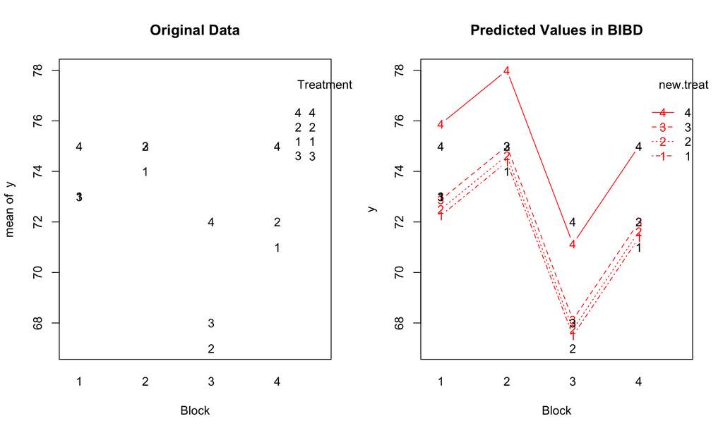

```r
## making new predictions on complete grid of blocks and treatment (for understanding the estimating process)
new.treat <- rep (as.character(1:4), 4)
new.block <- rep (as.character(1:4), each = 4)
new.data <- data.frame (Treatment=new.treat, Block = new.block)
new.pred <- predict (g, newdata = new.data)


## drawing interaction plots to look at the prediction
par (mfrow = c(1,2))
interaction.plot(Block, Treatment, y, type ="p", main = "Original Data",ylim = range (y, new.pred))

## plot predicted values
interaction.plot(new.block, new.treat, new.pred,
                 type = "b",col ="red", ylim = range (y, new.pred),
                 xlab = "Block", ylab = "y", main = "Predicted Values in BIBD")
## show original points on the previous plot
points (as.numeric(Block), y, pch = as.character(Treatment ))
```

```r
## fit another model (treatment then block)
g2<-lm(y ~  Treatment + Block, catalyst)
anova(g2)
```

|  | Df | Sum Sq | Mean Sq | F value | Pr(>F) |
| --- | --- | --- | --- | --- | --- |
| Treatment | 3 | 11.66667 | 3.888889 | 5.982906 | 0.0414634 |
| Block | 3 | 66.08333 | 22.027778 | 33.888889 | 0.0009528 |
| Residuals | 5 | 3.25000 | 0.650000 | NA | NA |

We see that the ordering makes differences in anova, although it does not change least square regression fitting.

## 4.2 Effect Comparison in BIBD

BIBD Effect Estimations is not exactly equal to treatment and block mean differences

```r
means.treat <- tapply(y, Treatment, mean); means.treat - means.treat[1]
```

```
##          1          2          3          4
##  0.0000000 -1.3333333 -0.6666667  1.3333333
```

```r
means.block <- tapply(y, Block, mean); means.block - means.block[1]
```

```
##         1         2         3         4
##  0.000000  1.000000 -4.666667 -1.000000
```

```r
## fixed pair means comparison (effect estimate differences)
summary (g)
```

```
##
## Call:
## lm(formula = y ~ Block + Treatment, data = catalyst)
##
## Residuals:
##          1          2          3          4          5          6          7
##  7.500e-01 -3.750e-01 -3.750e-01  3.750e-01 -7.500e-01  3.750e-01  1.250e-01
##          8          9         10         11         12
##  1.188e-14 -1.250e-01 -8.750e-01  8.750e-01  1.077e-14
##
## Coefficients:
##             Estimate Std. Error t value Pr(>|t|)
## (Intercept)  72.2500     0.6158 117.334 8.53e-10 ***
## Block2        2.1250     0.6982   3.043  0.02864 *
## Block3       -4.7500     0.6982  -6.803  0.00105 **
## Block4       -0.8750     0.6982  -1.253  0.26554
## Treatment2    0.2500     0.6982   0.358  0.73492
## Treatment3    0.6250     0.6982   0.895  0.41173
## Treatment4    3.6250     0.6982   5.192  0.00349 **
## ---
## Signif. codes:  0 '***' 0.001 '**' 0.01 '*' 0.05 '.' 0.1 ' ' 1
##
## Residual standard error: 0.8062 on 5 degrees of freedom
## Multiple R-squared:  0.9599, Adjusted R-squared:  0.9117
## F-statistic: 19.94 on 6 and 5 DF,  p-value: 0.002396
```

```r
confint (g)
```

```
##                  2.5 %     97.5 %
## (Intercept) 70.6671254 73.8328746
## Block2       0.3301889  3.9198111
## Block3      -6.5448111 -2.9551889
## Block4      -2.6698111  0.9198111
## Treatment2  -1.5448111  2.0448111
## Treatment3  -1.1698111  2.4198111
## Treatment4   1.8301889  5.4198111
```

```r
## multiple comparison
catalyst.tukeyci <- TukeyHSD(aov(y~Block+Treatment, data = catalyst)); catalyst.tukeyci
```

```
##   Tukey multiple comparisons of means
##     95% family-wise confidence level
##
## Fit: aov(formula = y ~ Block + Treatment, data = catalyst)
##
## $Block
##          diff       lwr       upr     p adj
## 2-1  1.000000 -1.428998  3.428998 0.4917130
## 3-1 -4.666667 -7.095665 -2.237669 0.0032954
## 4-1 -1.000000 -3.428998  1.428998 0.4917130
## 3-2 -5.666667 -8.095665 -3.237669 0.0013433
## 4-2 -2.000000 -4.428998  0.428998 0.0975482
## 4-3  3.666667  1.237669  6.095665 0.0096068
##
## $Treatment
##          diff        lwr      upr     p adj
## 2-1 0.2222222 -2.2067758 2.651220 0.9852477
## 3-1 0.5555556 -1.8734425 2.984554 0.8323947
## 4-1 3.2222222  0.7932242 5.651220 0.0165827
## 3-2 0.3333333 -2.0956647 2.762331 0.9540767
## 4-2 3.0000000  0.5710020 5.428998 0.0222012
## 4-3 2.6666667  0.2376686 5.095665 0.0352698
```

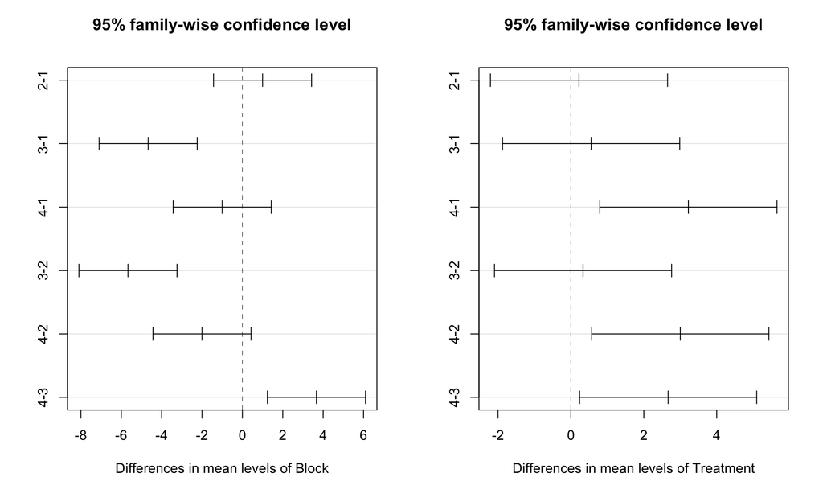

```r
par (mfrow = c(1,2))
plot (catalyst.tukeyci)
```

```r
catalyst.tukeyci2 <- TukeyHSD(aov(y~Treatment+Block, data = catalyst));
catalyst.tukeyci2
```

```
##   Tukey multiple comparisons of means
##     95% family-wise confidence level
##
## Fit: aov(formula = y ~ Treatment + Block, data = catalyst)
##
## $Treatment
##           diff        lwr      upr     p adj
## 2-1 -1.3333333 -3.7623314 1.095665 0.2923571
## 3-1 -0.6666667 -3.0956647 1.762331 0.7501716
## 4-1  1.3333333 -1.0956647 3.762331 0.2923571
## 3-2  0.6666667 -1.7623314 3.095665 0.7501716
## 4-2  2.6666667  0.2376686 5.095665 0.0352698
## 4-3  2.0000000 -0.4289980 4.428998 0.0975482
##
## $Block
##           diff        lwr        upr     p adj
## 2-1  1.8888889 -0.5401092  4.3178869 0.1167979
## 3-1 -4.2222222 -6.6512203 -1.7932242 0.0051736
## 4-1 -0.7777778 -3.2067758  1.6512203 0.6622480
## 3-2 -6.1111111 -8.5401092 -3.6821131 0.0009414
## 4-2 -2.6666667 -5.0956647 -0.2376686 0.0352698
## 4-3  3.4444444  1.0154464  5.8734425 0.0125455
```

```r
## compare to the analysis that considers Block first then Treatment
catalyst.tukeyci
```

```
##   Tukey multiple comparisons of means
##     95% family-wise confidence level
##
## Fit: aov(formula = y ~ Block + Treatment, data = catalyst)
##
## $Block
##          diff       lwr       upr     p adj
## 2-1  1.000000 -1.428998  3.428998 0.4917130
## 3-1 -4.666667 -7.095665 -2.237669 0.0032954
## 4-1 -1.000000 -3.428998  1.428998 0.4917130
## 3-2 -5.666667 -8.095665 -3.237669 0.0013433
## 4-2 -2.000000 -4.428998  0.428998 0.0975482
## 4-3  3.666667  1.237669  6.095665 0.0096068
##
## $Treatment
##          diff        lwr      upr     p adj
## 2-1 0.2222222 -2.2067758 2.651220 0.9852477
## 3-1 0.5555556 -1.8734425 2.984554 0.8323947
## 4-1 3.2222222  0.7932242 5.651220 0.0165827
## 3-2 0.3333333 -2.0956647 2.762331 0.9540767
## 4-2 3.0000000  0.5710020 5.428998 0.0222012
## 4-3 2.6666667  0.2376686 5.095665 0.0352698
```

```r
detach ("catalyst")
```

# 5 Analysis of Covariance (Accounting for Uncontrollable Continuous Covariates)

**Textbook section 15.3**

Consider an experiment (Flurry, 1939) to study the breaking strength (y) in grams of three types of starch film. The breaking strength is also known to depend on the thickness of the film (x) as measured in 10-4 inches. Because film thickness varies from run to run and its values cannot be controlled or chosen prior to the experiment, it should be treated as a covariate whose effect on strength needs to be accounted for before comparing the three types of starch.

```r
starch <- read.csv("data/starch2.txt")
starch$type <- factor (starch$type, levels = c("corn", "canna", "potato"))
knitr::kable(starch)
```

| strength | thickness | type |
| --- | --- | --- |
| 791.7 | 7.7 | canna |
| 610.0 | 6.3 | canna |
| 710.0 | 8.6 | canna |
| 940.7 | 11.8 | canna |
| 990.0 | 12.4 | canna |
| 916.2 | 12.0 | canna |
| 835.0 | 11.4 | canna |
| 724.3 | 10.4 | canna |
| 611.1 | 9.2 | canna |
| 621.7 | 9.0 | canna |
| 735.4 | 9.5 | canna |
| 990.0 | 12.5 | canna |
| 862.7 | 11.7 | canna |
| 731.0 | 8.0 | corn |
| 710.0 | 7.3 | corn |
| 604.7 | 7.2 | corn |
| 508.8 | 6.1 | corn |
| 393.0 | 6.4 | corn |
| 416.0 | 6.4 | corn |
| 400.0 | 6.9 | corn |
| 335.6 | 5.8 | corn |
| 306.4 | 5.3 | corn |
| 426.0 | 6.7 | corn |
| 382.5 | 5.8 | corn |
| 340.8 | 5.7 | corn |
| 436.7 | 6.1 | corn |
| 333.3 | 6.2 | corn |
| 382.3 | 6.3 | corn |
| 397.7 | 6.0 | corn |
| 619.1 | 6.8 | corn |
| 857.3 | 7.9 | corn |
| 592.5 | 7.2 | corn |
| 983.3 | 13.0 | potato |
| 958.8 | 13.3 | potato |
| 747.8 | 10.7 | potato |
| 866.0 | 12.2 | potato |
| 810.8 | 11.6 | potato |
| 950.0 | 9.7 | potato |
| 1282.0 | 10.8 | potato |
| 1233.8 | 10.1 | potato |
| 1660.0 | 12.7 | potato |
| 746.0 | 9.8 | potato |
| 650.0 | 10.0 | potato |
| 992.5 | 13.8 | potato |
| 896.7 | 13.3 | potato |
| 873.9 | 12.4 | potato |
| 924.4 | 12.2 | potato |
| 1050.0 | 14.1 | potato |
| 973.3 | 13.7 | potato |

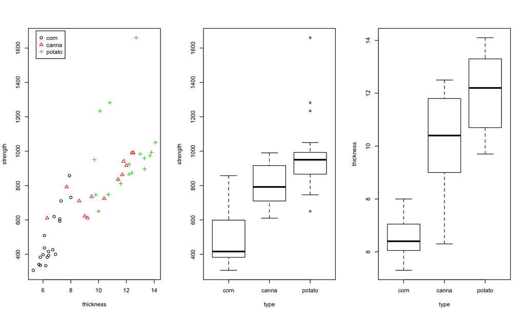

```r
attach (starch)

## look at data
par (mfrow=c(1,3))
plot (strength~thickness,pch = as.numeric(type), col =type);
legend (5.5,1700,  legend=levels(type), pch = 1:3, col=1:3 )
plot (strength~type)
plot (thickness~type)
```

## 5.1 Analysis 1-1: Considering ‘Type’ only, no ‘thickness’

```r
fit1_typeonly <- lm (strength~type)
anova.R2 (fit1_typeonly)
```

|  | Df | Sum Sq | Mean Sq | F value | Pr(>F) | R2 |
| --- | --- | --- | --- | --- | --- | --- |
| type | 2 | 2246204 | 1123102.19 | 32.6191 | 0 | 0.586473 |
| Residuals | 46 | 1583818 | 34430.82 | NA | NA | 0.413527 |

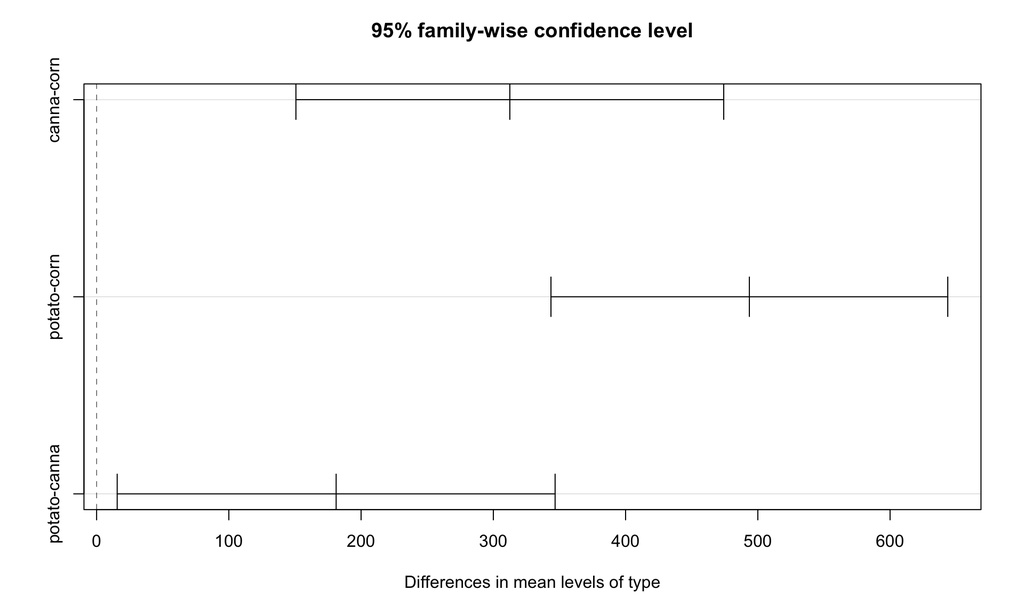

```r
par (mfrow = c(1,1))
plot(TukeyHSD(aov(strength~type)))
```

```r
## we see that there is great difference in thickness between starch types
```

## 5.2 Analysis 1-2: Considering ‘thickness’ only, no ‘Type’

```r
#fit_starch0 <- lm (strength~1)
fit_starch1 <- lm (strength~thickness)
coefficients(fit_starch1)
```

```
## (Intercept)   thickness
##   -43.46202    83.13356
```

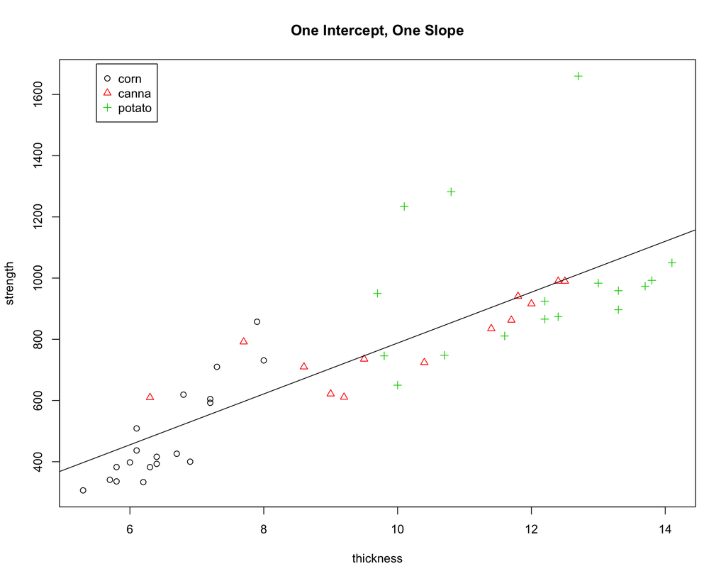

```r
## looking at the prediction
plot (strength~thickness,pch = as.numeric(type), col =type, main = "One Intercept, One Slope");
legend (5.5,1700,  legend=levels(type), pch = 1:3, col=1:3 )
abline (fit_starch1)
```

```r
anova.R2 (fit_starch1)
```

|  | Df | Sum Sq | Mean Sq | F value | Pr(>F) | R2 |
| --- | --- | --- | --- | --- | --- | --- |
| thickness | 1 | 2553357 | 2553357.20 | 94.00102 | 0 | 0.6666691 |
| Residuals | 47 | 1276665 | 27163.08 | NA | NA | 0.3333309 |

## 5.3 Analysis 2-1: Considering “thickness” and then “type”

```r
#anova (fit_starch0, fit_starch1, fit_starch2)
## anova itself uses the above sequence in producing the anova table
fit_starch2<-lm(strength~thickness+type)
coefficients(fit_starch2)
```

```
## (Intercept)   thickness   typecanna  typepotato
##    74.59478    62.50120    83.66605   154.02614
```

```r
## look at the design matrix to understand the coefficients

model.matrix(fit_starch2)
```

```
##    (Intercept) thickness typecanna typepotato
## 1            1       7.7         1          0
## 2            1       6.3         1          0
## 3            1       8.6         1          0
## 4            1      11.8         1          0
## 5            1      12.4         1          0
## 6            1      12.0         1          0
## 7            1      11.4         1          0
## 8            1      10.4         1          0
## 9            1       9.2         1          0
## 10           1       9.0         1          0
## 11           1       9.5         1          0
## 12           1      12.5         1          0
## 13           1      11.7         1          0
## 14           1       8.0         0          0
```

[output cut: 40 more lines]

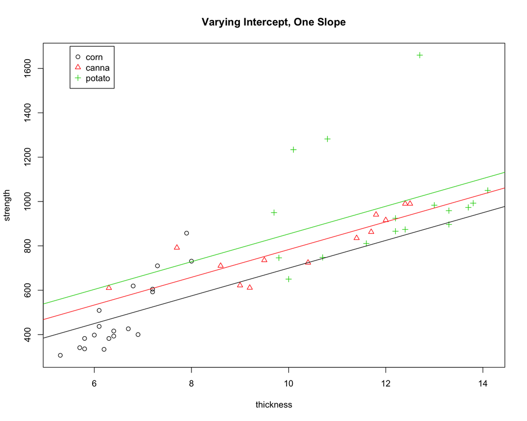

```r
## look at the prediction to understand the fitting
plot (strength~thickness,pch = as.numeric(type), col =type,
      main = "Varying Intercept, One Slope");
legend (5.5,1700,  legend= levels(type), pch = 1:3, col=1:3)
#abline (fit_starch1, lwd=2)
coef.fit2 <- coefficients(fit_starch2)
abline (a = coef.fit2[1], b= coef.fit2[2], col = 1)
abline (a = coef.fit2[1]+ coef.fit2[3], b = coef.fit2[2] ,col =2)
abline (a = coef.fit2[1]+ coef.fit2[4], b = coef.fit2[2] ,col =3)
```

```r
## anova
anova.R2 (fit_starch2)
```

|  | Df | Sum Sq | Mean Sq | F value | Pr(>F) | R2 |
| --- | --- | --- | --- | --- | --- | --- |
| thickness | 1 | 2553357.20 | 2553357.20 | 94.185852 | 0.0000000 | 0.6666691 |
| type | 2 | 56724.87 | 28362.44 | 1.046207 | 0.3596542 | 0.0148106 |
| Residuals | 45 | 1219939.85 | 27109.77 | NA | NA | 0.3185203 |

## 5.4 Analysis 2-2: Considering “type” then “thickness” (wrong for this question)

```r
fit_starch4<-lm(strength~type+thickness)
coefficients(fit_starch4)
```

```
## (Intercept)   typecanna  typepotato   thickness
##    74.59478    83.66605   154.02614    62.50120
```

**Note that linear model estimation is the same as analysis 2-1, but anova will be different**

```r
anova.R2 (fit_starch4)
```

|  | Df | Sum Sq | Mean Sq | F value | Pr(>F) | R2 |
| --- | --- | --- | --- | --- | --- | --- |
| type | 2 | 2246204.4 | 1123102.19 | 41.42794 | 0.0000000 | 0.5864730 |
| thickness | 1 | 363877.7 | 363877.69 | 13.42238 | 0.0006526 | 0.0950067 |
| Residuals | 45 | 1219939.9 | 27109.77 | NA | NA | 0.3185203 |

Note that the ordering of variables matters in producing ANOVA table.

## 5.5 Analyzing Starch Data Again: Varying Slopes (Interaction)

```r
## we can fit better if allow intercept and slope both varying (interaction)

fit_starch5<-lm(strength~thickness*type)
summary (fit_starch5)
```

```
##
## Call:
## lm(formula = strength ~ thickness * type)
##
## Residuals:
##     Min      1Q  Median      3Q     Max
## -262.56  -83.31  -18.84   47.20  659.67
##
## Coefficients:
##                      Estimate Std. Error t value Pr(>|t|)
## (Intercept)           -751.04     323.32  -2.323  0.02499 *
## thickness              188.91      49.20   3.839  0.00040 ***
## typecanna              942.01     399.62   2.357  0.02303 *
## typepotato            1338.49     446.49   2.998  0.00451 **
## thickness:typecanna   -129.62      54.17  -2.393  0.02116 *
## thickness:typepotato  -156.40      55.44  -2.821  0.00721 **
## ---
## Signif. codes:  0 '***' 0.001 '**' 0.01 '*' 0.05 '.' 0.1 ' ' 1
##
## Residual standard error: 154.7 on 43 degrees of freedom
## Multiple R-squared:  0.7314, Adjusted R-squared:  0.7002
## F-statistic: 23.42 on 5 and 43 DF,  p-value: 2.774e-11
```

```r
coef.fit5 <- coefficients(fit_starch5); knitr::kable(coef.fit5)
```

|  | x |
| --- | --- |
| (Intercept) | -751.0374 |
| thickness | 188.9074 |
| typecanna | 942.0086 |
| typepotato | 1338.4945 |
| thickness:typecanna | -129.6155 |
| thickness:typepotato | -156.3974 |

```r
## look at the design matrix to understand the coefficient

data.frame(model.matrix (fit_starch5))
```

| X.Intercept. | thickness | typecanna | typepotato | thickness.typecanna | thickness.typepotato |
| --- | --- | --- | --- | --- | --- |
| 1 | 7.7 | 1 | 0 | 7.7 | 0.0 |
| 1 | 6.3 | 1 | 0 | 6.3 | 0.0 |
| 1 | 8.6 | 1 | 0 | 8.6 | 0.0 |
| 1 | 11.8 | 1 | 0 | 11.8 | 0.0 |
| 1 | 12.4 | 1 | 0 | 12.4 | 0.0 |
| 1 | 12.0 | 1 | 0 | 12.0 | 0.0 |
| 1 | 11.4 | 1 | 0 | 11.4 | 0.0 |
| 1 | 10.4 | 1 | 0 | 10.4 | 0.0 |
| 1 | 9.2 | 1 | 0 | 9.2 | 0.0 |
| 1 | 9.0 | 1 | 0 | 9.0 | 0.0 |
| 1 | 9.5 | 1 | 0 | 9.5 | 0.0 |
| 1 | 12.5 | 1 | 0 | 12.5 | 0.0 |
| 1 | 11.7 | 1 | 0 | 11.7 | 0.0 |
| 1 | 8.0 | 0 | 0 | 0.0 | 0.0 |
| 1 | 7.3 | 0 | 0 | 0.0 | 0.0 |
| 1 | 7.2 | 0 | 0 | 0.0 | 0.0 |
| 1 | 6.1 | 0 | 0 | 0.0 | 0.0 |
| 1 | 6.4 | 0 | 0 | 0.0 | 0.0 |
| 1 | 6.4 | 0 | 0 | 0.0 | 0.0 |
| 1 | 6.9 | 0 | 0 | 0.0 | 0.0 |
| 1 | 5.8 | 0 | 0 | 0.0 | 0.0 |
| 1 | 5.3 | 0 | 0 | 0.0 | 0.0 |
| 1 | 6.7 | 0 | 0 | 0.0 | 0.0 |
| 1 | 5.8 | 0 | 0 | 0.0 | 0.0 |
| 1 | 5.7 | 0 | 0 | 0.0 | 0.0 |
| 1 | 6.1 | 0 | 0 | 0.0 | 0.0 |
| 1 | 6.2 | 0 | 0 | 0.0 | 0.0 |
| 1 | 6.3 | 0 | 0 | 0.0 | 0.0 |
| 1 | 6.0 | 0 | 0 | 0.0 | 0.0 |
| 1 | 6.8 | 0 | 0 | 0.0 | 0.0 |
| 1 | 7.9 | 0 | 0 | 0.0 | 0.0 |
| 1 | 7.2 | 0 | 0 | 0.0 | 0.0 |
| 1 | 13.0 | 0 | 1 | 0.0 | 13.0 |
| 1 | 13.3 | 0 | 1 | 0.0 | 13.3 |
| 1 | 10.7 | 0 | 1 | 0.0 | 10.7 |
| 1 | 12.2 | 0 | 1 | 0.0 | 12.2 |
| 1 | 11.6 | 0 | 1 | 0.0 | 11.6 |
| 1 | 9.7 | 0 | 1 | 0.0 | 9.7 |
| 1 | 10.8 | 0 | 1 | 0.0 | 10.8 |
| 1 | 10.1 | 0 | 1 | 0.0 | 10.1 |
| 1 | 12.7 | 0 | 1 | 0.0 | 12.7 |
| 1 | 9.8 | 0 | 1 | 0.0 | 9.8 |
| 1 | 10.0 | 0 | 1 | 0.0 | 10.0 |
| 1 | 13.8 | 0 | 1 | 0.0 | 13.8 |
| 1 | 13.3 | 0 | 1 | 0.0 | 13.3 |
| 1 | 12.4 | 0 | 1 | 0.0 | 12.4 |
| 1 | 12.2 | 0 | 1 | 0.0 | 12.2 |
| 1 | 14.1 | 0 | 1 | 0.0 | 14.1 |
| 1 | 13.7 | 0 | 1 | 0.0 | 13.7 |

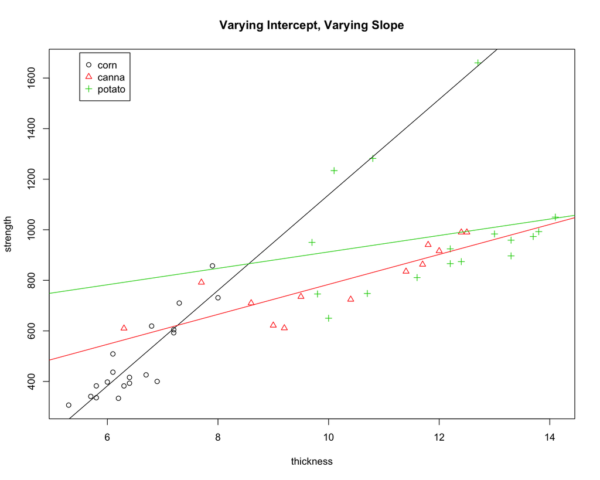

```r
## looking at the prediction to understand the fitting
par (mfrow = c(1,1))
plot (strength~thickness,pch = as.numeric(type), col =type,
      main = "Varying Intercept, Varying Slope");
legend (5.5,1700,  legend=levels(type), pch = 1:3, col=1:3 )
#abline (fit_starch1, lwd=2)
coef.fit2 <- coefficients(fit_starch2)
abline (a = coef.fit5[1], b= coef.fit5[2], col = 1)
abline (a = coef.fit5[1]+ coef.fit5[3], b = coef.fit5[2] + coef.fit5[5] ,col =2)
abline (a = coef.fit5[1]+ coef.fit5[4], b = coef.fit5[2] + coef.fit5[6],col =3)
```

```r
anova.R2 (fit_starch5)-> anova.fit5; anova.fit5
```

|  | Df | Sum Sq | Mean Sq | F value | Pr(>F) | R2 |
| --- | --- | --- | --- | --- | --- | --- |
| thickness | 1 | 2553357.20 | 2553357.20 | 106.741403 | 0.0000000 | 0.6666691 |
| type | 2 | 56724.87 | 28362.44 | 1.185673 | 0.3153306 | 0.0148106 |
| thickness:type | 2 | 191338.42 | 95669.21 | 3.999388 | 0.0255292 | 0.0499575 |
| Residuals | 43 | 1028601.43 | 23920.96 | NA | NA | 0.2685628 |

**The most resonable way to account for the contribution of “type” should be comparing these two models.**

```r
fit_starch_thicknessonly <- lm (strength~thickness)
fit_startch_thickness.type.interaction <- lm (strength~thickness*type)
anova (fit_starch_thicknessonly, fit_startch_thickness.type.interaction)
```

| Res.Df | RSS | Df | Sum of Sq | F | Pr(>F) |
| --- | --- | --- | --- | --- | --- |
| 47 | 1276665 | NA | NA | NA | NA |
| 43 | 1028601 | 4 | 248063.3 | 2.59253 | 0.0497493 |

```r
## R^2 (percentage of reduction of RSS) after considering "type" is about 19%
248063 / 1276665
```

```
## [1] 0.1943055
```

## 5.6 Which model should we choose to interpret? Using AIC

**Notes: not required for this course**

AIC is an estimate of the leave-one-out predictive accuracy, a value related to SSE but penalized by the number of model parameters.

```r
AIC (fit_startch_thickness.type.interaction) # thickness*type
```

```
## [1] 640.6986
```

```r
AIC( fit_starch4) # thickness+type
```

```
## [1] 645.0581
```

```r
AIC( fit_starch1) # thickness only
```

```
## [1] 643.2851
```

```r
AIC( fit1_typeonly) # type only
```

```
## [1] 655.8489
```

The model considering the interaction between thickness and type has the lowest AIC value, which means that it has the best out-of-sample predictive ability. Our conclusion should be based on this model.

The model considering thickness+type has lower predictive accuracy than the model considering thickness only. This is another approach to conclude that the type of starch does not affect the mean of the strengthness of films. After considering the interaction between the thickness and the type of starch, we discover that the type of starch affects the slope between the strengthness and thickness.

```r
detach ("starch")
```